# Présentation et illustration de l'écosystème Python pour la data science

**Francis Wolinski**

@fran6wol

**Yotta Conseil** - **Paris 1**

## Journée Python et Data Science

**IRMAR**

Rennes - 19 décembre 2017

## Présentation du langage Python

- Programmation par objets permettant un style de programmation fonctionnelle
- Syntaxe élégante et concise
- Large bibliothèque de modules et d’extensions
- Interprété et disposant d’un mode de programmation interactive
- Portable sur Linux, Mac OS X et Windows...
- Open source et supporté par la Python Software Foundation

```python
# Hello World!

def hello_world():
    print("Hello World!")

hello_world()
```

```
Hello World!
```

```python
# list comprehension

[i * i for i in range(10)]
```

```
[0, 1, 4, 9, 16, 25, 36, 49, 64, 81]
```

```python
# set comprehension

{i * i for i in range(-10, 11) if i % 2 == 1}
```

```
{1, 9, 25, 49, 81}
```

```python
# range & slicing

a = range(100)
b = a[0:100:2]
print(list(b))
```

```
[0, 2, 4, 6, 8, 10, 12, 14, 16, 18, 20, 22, 24, 26, 28, 30, 32, 34, 36, 38, 40, 42, 44, 46, 48, 50, 52, 54, 56, 58, 60, 62, 64, 66, 68, 70, 72, 74, 76, 78, 80, 82, 84, 86, 88, 90, 92, 94, 96, 98]
```

```python
b[10:20:3]
```

```
range(20, 40, 6)
```

## Les 3 étapes du langage Python

- Les années 1990 : Python 1
  - Langage de script
  - Une alternative à bash
- Les années 2000 : Python 2
  - Calcul scientifique
  - Une alternative à MATLAB
- Les années 2010 : Python 3
  - Data science
  - Une alternative à R

*Source : Jake VanderPlas (University of Washington)*

# Le succès actuel de Python

[figure not shown]

*Python has continued its upward trajectory from last year and jumped two places to the No. 1 slot, though the top four—Python, C, Java, and C++—all remain very close in popularity.*

Source IEEE : https://spectrum.ieee.org/computing/software/the-2017-top-programming-languages

## Python : un langage universel

[figure not shown]

## Python et la data science

[figure not shown]

*Python, whose usage has been growing faster than R for the last several years, has finally caught up with R, and (barely) overtook it, with 52.6% respondents using it v. 52.1% for R.*

Source : KDNuggets 2017 Poll http://www.kdnuggets.com/2017/05/poll-analytics-data-science-machine-learning-software-leaders.html

# Ecosystème Python pour la Data Science

[figure not shown]

## Succès des librairies Python

[figure not shown]

Source : David Robison – Why is Python Growing So Quickly ? https://stackoverflow.blog/2017/09/14/python-growing-quickly/

```python
# launch spyder

%run C:/Test/Anaconda3/Scripts/spyder-script.py
```

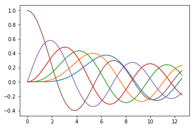

```python
# fonctions de Bessel

from numpy import linspace, pi
from scipy.special import jn
from matplotlib.pylab import plot

%matplotlib inline

x = linspace(0, 4*pi)
for i in range(5,-1,-1):
    plot(x, jn(i, x))
```

$J_\nu (x) = \sum_{n=0}^\infty \frac{(-1)^n}{n! \cdot \Gamma(n+1+\nu)} \left ( \frac{x}{2} \right )^{2n+\nu}$

# La révolution Jupyter

[figure not shown]

```python
# Interface multimedia
from IPython.display import IFrame
IFrame("http://calcul.math.cnrs.fr/spip.php?article287", width=800, height=600)
```

[interactive chart not shown]

## NumPy

Librairie destinée à manipuler des matrices ou tableaux multidimensionnels ainsi que des fonctions mathématiques opérant sur ces tableaux

**Caractéristiques principales**

- Structure de données ndarray (N-dimentional array) typée dtype (data-type)
- Calculs vectoriel et matriciel
- Algèbre linéaire, nombres aléatoires, transformations de Fourier...
- Outils pour intégrer du C++ et du Fortran

```python
# Performances de Python vs NumPy

# boucle Python
%timeit [i * i for i in range(10000000)]
```

```
1 loop, best of 3: 943 ms per loop
```

```python
# ufunc NumPy
import numpy as np
%timeit np.arange(1e7) ** 2
```

```
10 loops, best of 3: 63.3 ms per loop
```

## Matplotlib

Librairie destinée à tracer et visualiser des données sous formes de graphiques 2D

**Caractéristiques principales**

- Graphes de fonctions
- Histogrammes
- Diagrammes de densité
- Graphiques en barres et secteurs
- Nuages de points

**Nouvelles librairies**

- seaborn: statistical data visualization
- bokeh: statistical and novel interactive HTML plots for Python

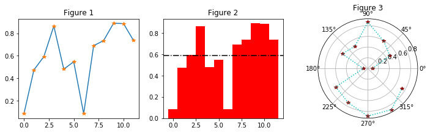

```python
import matplotlib.pyplot as plt
x = np.random.random(12)
fig = plt.figure(figsize=(12, 3))
ax1 = fig.add_subplot(131)
ax1.set_title("Figure 1")
ax1.plot(x)
ax1.plot(x, '*')
ax2 = fig.add_subplot(132)
ax2.set_title("Figure 2")
ax2.bar(np.arange(12), x, 1, color='r')
ax2.axhline(x.mean(), color='k', linestyle='-.')
ax3 = fig.add_subplot(133, projection='polar')
ax3.set_title("Figure 3")
r = np.linspace(0, (2 - 1 / 6) * np.pi, 12)
ax3.plot(r, x, '*', color='darkred')
ax3.plot(r, x, 'c:');
```

## SciPy

Librairie visant à unifier et fédérer un ensemble de librairies Python à usage scientifique

**Caractéristiques principales**

- Statistiques
- Lois discrètes ou continues
- Statistiques descriptives
- Tests statistiques
- Optimisation
- Algèbre linéaire
- Matrices creuses
- Traitement du signal et d'images

```
mu=6.00, std=3.00
```

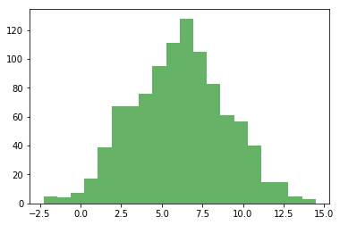

```python
# random normal distribution
mu = np.random.randint(10)
std = np.random.randint(1, 4)
print("mu={:.2f}, std={:.2f}".format(mu, std))
a = np.random.normal(mu, std, 1000)
plt.hist(a, bins=20, color='g', alpha=0.6);
```

```
mu=6.13, std=2.89
```

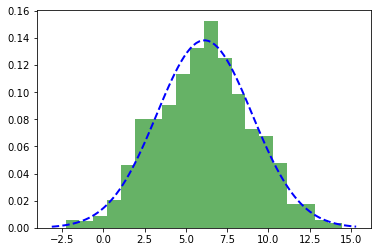

```python
# estimation of a normal distribution
from scipy.stats import norm
mu, std = norm.fit(a)
print("mu={0:.2f}, std={1:.2f}".format(mu, std))
plt.hist(a, bins=20, normed=True, color='g', alpha=0.6)
xmin, xmax = plt.xlim()
x = np.linspace(xmin, xmax, 100)
y = norm.pdf(x, mu, std)
plt.plot(x, y, 'b--', linewidth=2);
```

## Pandas

Librairie fournissant des structures de données et les outils d’analyse associés performants et faciles à utiliser

**Caractéristiques principales**

- Structure 1D : Series
- Structure 2D : DataFrame
- Intégrée avec NumPy, SciPy et matplotlib…

```python
import pandas as pnd
df = pnd.read_csv("c:/Test/mydata/irmar/nat2015.txt",
                  sep="\t",
                  encoding='latin-1')
df.head(10)
```

|  | sexe | preusuel | annais | nombre |
| --- | --- | --- | --- | --- |
| 0 | 1 | A | 1980 | 3.0 |
| 1 | 1 | A | 1998 | 3.0 |
| 2 | 1 | A | XXXX | 21.0 |
| 3 | 1 | AADEL | 1976 | 5.0 |
| 4 | 1 | AADEL | 1978 | 3.0 |
| 5 | 1 | AADEL | 1980 | 3.0 |
| 6 | 1 | AADEL | 1981 | 5.0 |
| 7 | 1 | AADEL | 1982 | 4.0 |
| 8 | 1 | AADEL | 1983 | 3.0 |
| 9 | 1 | AADEL | 1987 | 5.0 |

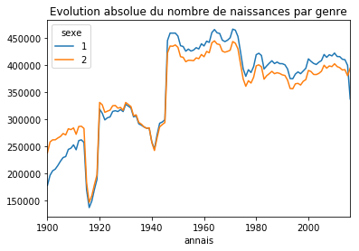

```python
tab = df.pivot_table(index="annais", columns="sexe", values="nombre", aggfunc="sum")
tab.plot(title="Evolution absolue du nombre de naissances par genre");
```

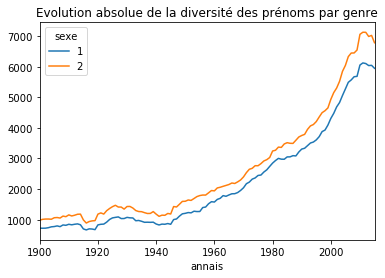

```python
df = df.loc[df["annais"] != "XXXX"]
tab = df.pivot_table(index="annais", columns="sexe", values="preusuel", aggfunc="count")
tab.plot(title="Evolution absolue de la diversité des prénoms par genre");
```

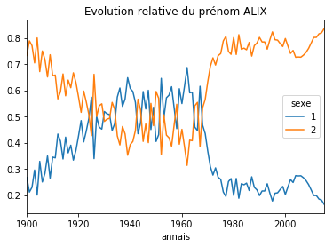

```python
def evol_prenom(prenom):
    sel = df.loc[df['preusuel'] == prenom]
    evol = sel.pivot_table(index='annais',
                         columns='sexe',
                         values='nombre',
                         aggfunc='sum')
    tab = evol.div(evol.sum(axis=1), axis=0)
    tab.plot(title="Evolution relative du prénom {}".format(prenom));

evol_prenom('ALIX')
```

## scikit-learn

Librairie de machine learning et de data mining

**Caractéristiques principales**

- Classification (SVM, plus proches voisins, random forest…)
- Régression (linéaire, logistique…)
- Clustering (partitionnement en k-means, …)
- Réduction de dimension (analyse en composantes principales, …)
- Sélection de modèle (validations croisées…)
- Intégrée avec NumPy, SciPy et matplotlib
- Keras (réseaux de neurones) fournit une API à la scikit-learn

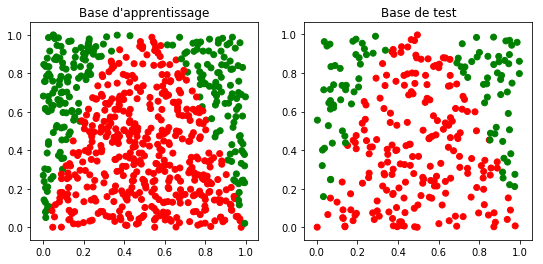

```python
from sklearn.model_selection import train_test_split

X = np.random.random((2, 1000))
y = X[1] > np.sin(np.pi * X[0])
X_train, X_test, y_train, y_test = train_test_split(X.T, y, test_size=0.3)

c_train = np.where(y_train, ['g'] * len(y_train), ['r'] * len(y_train))
c_test = np.where(y_test, ['g'] * len(y_test), ['r'] * len(y_test))

fig = plt.figure(figsize=(9, 4))
ax1 = fig.add_subplot(121)
ax1.set_title("Base d'apprentissage")
ax1.scatter(X_train.T[0], X_train.T[1], color=c_train)
ax2 = fig.add_subplot(122)
ax2.set_title("Base de test")
ax2.scatter(X_test.T[0], X_test.T[1], color=c_test);
```

```python
from sklearn.linear_model import LogisticRegression
from sklearn.svm import SVC
from sklearn.neural_network import MLPClassifier
from sklearn.tree import DecisionTreeClassifier
from sklearn.ensemble import RandomForestClassifier

from sklearn.metrics import accuracy_score
```

```
Accuracy:  0.98%
```

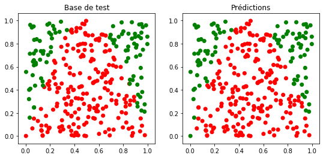

```python
algo = RandomForestClassifier()

algo.fit(X_train, y_train)
y_pred = algo.predict(X_test)
c_pred = np.where(y_pred, ['g'] * len(y_pred), ['r'] * len(y_pred))

acc_test = accuracy_score(y_test, y_pred)
print("Accuracy:  {:.2f}%".format(acc_test))

fig = plt.figure(figsize=(9, 4))
ax1 = fig.add_subplot(121)
ax1.set_title("Base de test")
ax1.scatter(X_test.T[0], X_test.T[1], color=c_test)
ax2 = fig.add_subplot(122)
ax2.set_title("Prédictions")
ax2.scatter(X_test.T[0], X_test.T[1], color=c_pred);
```

## Conclusion et Références

- Travis Oliphant – Guide to NumPy (2015)
- Jake VanderPlas - Python Data Science Handbook (2016)
- Wes McKinney - Python for Data Analysis: Data Wrangling with Pandas, Numpy, and IPython (2017)
- Python https://www.python.org/
- SciPy https://www.scipy.org/
- NumPy http://www.numpy.org/
- Pandas http://pandas.pydata.org/
- Matplotlib https://matplotlib.org/
- Scikit Learn http://scikit-learn.org
- Jupyter http://jupyter.org/
- Anaconda https://www.anaconda.com/
- NumFocus https://www.numfocus.org/